# R Notebook

# 2.7 coercion

we said that vectors must be all of the same type. so if we try to combine, say, numbers and characters, you might expect an error:

```r
x<- c(1, "canada", 3)
```

but we don’t get one, not even a warning! what happened? look at *x* and its class:

```r
x
```

```
[1] "1"      "canada" "3"
```

```r
class(x)
```

```
[1] "character"
```

R coerced the data into characters. it guessed that becuase you put a character string in the vector, you meant the 1 and 3 to actually be character strings *1* and *3*. the fact that not even a warning is issued is an example of how coercion can cause many unnoticed errors in R.

R also offers functions to change from one type to another. for example, you can turn numbers into characters with:

```r
x<- 1:5
y<- as.character(x)
y
```

```
[1] "1" "2" "3" "4" "5"
```

you can turn it back with *as.numeric*:

```r
as.numeric(y)
```

```
[1] 1 2 3 4 5
```

this function is actually quite useful since datasets that include numbers as character strings are common.

# 2.7.1 not availables (NA)

when a function tries to coerce one type to another and encounters an impossible case, it usually gives us a warning and turns the entry into a special value called an *NA* for “not available”. For example:

```r
x<- c("1", "b", "3")
as.numeric(x)
```

```
NAs introduced by coercion
```

```
[1]  1 NA  3
```

R does not have any guesses for what number you want when you type *b*, so it does not try.

as a data scientist you will encounter the *NA* often as they are generally used for missing data, a common problem in real-word datasets.

# 2.8 exercises

1. use the function *c* to create a vector with the average high temperatures in January for Beijing, Lagos, Paris, Rio de Janeiro, San Juan, and Toronto, which are 35, 88, 42, 84, 81, and 30 degrees Fahrenheit. call the object *temp*.

```r
temp<- c(35, 88, 42, 84, 81, 30)
```

2. now create a vector with the city names and call the object *city*.

```r
city<- c("Beijing", "Lagos", "Paris", "Rio de Janeiro", "San Juan", "Toronto")
```

3. use the *names* function and the objects defined in the previous exercises to associate the temperature data with its corresponding city.

```r
names(temp)<- city
```

4. Use the *[* and *:* operators to access the temperature of the first three cities on the list.

```r
temp[1:3]
```

```
Beijing   Lagos   Paris
     35      88      42
```

5. use the *[* operator to access the temperature of Paris and San Juan.

```r
temp[c("Paris", "San Juan")]
```

```
   Paris San Juan
      42       81
```

6. use the *:* operator to create a sequence of numbers 12,13,14,…,73.

```r
c(12:73)
```

```
 [1] 12 13 14 15 16 17 18 19 20 21 22 23 24 25 26 27 28 29 30 31 32 33
[23] 34 35 36 37 38 39 40 41 42 43 44 45 46 47 48 49 50 51 52 53 54 55
[45] 56 57 58 59 60 61 62 63 64 65 66 67 68 69 70 71 72 73
```

7. create a vector containing all the positive odd numbers smaller than 100.

```r
seq(1,99,2)
```

```
 [1]  1  3  5  7  9 11 13 15 17 19 21 23 25 27 29 31 33 35 37 39 41 43
[23] 45 47 49 51 53 55 57 59 61 63 65 67 69 71 73 75 77 79 81 83 85 87
[45] 89 91 93 95 97 99
```

8. create a vector of numbers that starts at 6, does not pass 55, and adds numbers in increments of 4/7: 6, 6+4/7, 6+8/7, and so on. how many numbers does the list have?

```r
length(seq(6, 55, 4/7))
```

```
[1] 86
```

9. what is the class of the following object *a<- seq(1,10,0.5)* ?

```r
a<- seq(1, 10, 0.5)
class(a)
```

```
[1] "numeric"
```

10. what is the class of the following object *a<- seq(1, 10)*?

```r
a<- seq(1, 10)
class(a)
```

```
[1] "integer"
```

11. the class of *class(a<-1)* is numeric, not integer. R defaults to numeric and to force an integer, you need to add the letter *L*. confirm that the class of *1L* is integer.

```r
class(a<-1)
```

```
[1] "numeric"
```

```r
class(a<-1L)
```

```
[1] "integer"
```

12. define the following vector:

```r
x<- c("1", "3", "5")
```

and coerce it to get integers.

```r
x<- c("1", "3", "5")
as.integer(x)
```

```
[1] 1 3 5
```

# 2.9.1 sort

say we want to rank the states from least most gun murders. the function *sort* sorts a vector in increasing order. we can therefore see the largest number of gun murders by typing:

```r
library(dslabs)
data(murders)
sort(murders$total)
```

```
 [1]    2    4    5    5    7    8   11   12   12   16   19   21   22
[14]   27   32   36   38   53   63   65   67   84   93   93   97   97
[27]   99  111  116  118  120  135  142  207  219  232  246  250  286
[40]  293  310  321  351  364  376  413  457  517  669  805 1257
```

# 2.9.2 order

the function *order* is closer to what we want. It takes a vector as input and returns the vector of indexes that sorts the input vector. this may sound confusing so let’s look at a simple example. we can create a vector and sort it:

```r
x<- c(31, 4, 15, 92, 65)
sort(x)
```

```
[1]  4 15 31 65 92
```

rather than sort the input vector, the function *order* returns the index that sorts input vector:

```r
index<- order(x)
x[index]
```

```
[1]  4 15 31 65 92
```

this is the same output as that returned by *sort(x)*. if we look at this index, we see why it works:

```r
x
```

```
[1] 31  4 15 92 65
```

```r
order(x)
```

```
[1] 2 3 1 5 4
```

the second entry of *x* is the smallest, so *order(x)* starts with *2*. the next smallest is the third entry, so the second entry is *3* and so on.

how does this help us order the states by murders? first, remember that the entries of vectors you access with *$* follow the same order as the rows in the table. for example, these two vectors containing state names and abbreviations, respectively, are matched by their order:

```r
murders$state[1:6]
```

```
[1] "Alabama"    "Alaska"     "Arizona"    "Arkansas"   "California"
[6] "Colorado"
```

```r
murders$abb[1:6]
```

```
[1] "AL" "AK" "AZ" "AR" "CA" "CO"
```

this means we can order the state names by their total murders. we first obtain the index that orders the vectors according to murder totals and then index the state names vector:

```r
index <- order(murders$total)
murders$abb[index]
```

```
 [1] "VT" "ND" "NH" "WY" "HI" "SD" "ME" "ID" "MT" "RI" "AK" "IA" "UT"
[14] "WV" "NE" "OR" "DE" "MN" "KS" "CO" "NM" "NV" "AR" "WA" "CT" "WI"
[27] "DC" "OK" "KY" "MA" "MS" "AL" "IN" "SC" "TN" "AZ" "NJ" "VA" "NC"
[40] "MD" "OH" "MO" "LA" "IL" "GA" "MI" "PA" "NY" "FL" "TX" "CA"
```

according to the above, california had the most murders.

# 2.9.3 max and which.max

if we are only interested in the entry with the largest value, we can use *max* for the value:

```r
max(murders$total)
```

```
[1] 1257
```

and *which.max* for the index of the largest value

```r
i_max<- which.max(murders$total)
murders$state[i_max]
```

```
[1] "California"
```

for the minimum, we can use *min* and *which.min* in the same way.

# 2.9.4 rank

although not as frequently used as *order* and *sort*, the function *rank* is also related to order and can be useful. for any given vector it returns a vector with the rank of the first entry, second entry, etc, of the input vector.

```r
x<- c(31, 4, 15, 92, 65)
rank(x)
```

```
[1] 3 1 2 5 4
```

# 2.9.5 beware of recycling

another common source of unnoticed errors in R is the use of recycling. we saw that vectors are added elementwise. so if the vectors don’t match in length, it is natural to assume that we should get an error. but we don’t. notice what happens:

```r
x<- c(1,2,3)
y<- c(10, 20, 30, 40, 50, 60, 70)
x+y
```

```
longer object length is not a multiple of shorter object length
```

```
[1] 11 22 33 41 52 63 71
```

we do get a warning, but no error. for the output, R has recycled the numbers in *x*. notice the last digit of numbers in the output.

# 2.10 exercises

for these exercises we will use the US murders dataset. make sure you load it prior to starting.

```r
library(dslabs)
data("murders")
```

1. use the *$* operator to access the population size data and store it as the object *pop*. then use the *sort* function to redefine *pop* so that it is sorted. finally use the *[* operator to report the smallest population size.

```r
murders$population
```

```
 [1]  4779736   710231  6392017  2915918 37253956  5029196  3574097
 [8]   897934   601723 19687653  9920000  1360301  1567582 12830632
[15]  6483802  3046355  2853118  4339367  4533372  1328361  5773552
[22]  6547629  9883640  5303925  2967297  5988927   989415  1826341
[29]  2700551  1316470  8791894  2059179 19378102  9535483   672591
[36] 11536504  3751351  3831074 12702379  1052567  4625364   814180
[43]  6346105 25145561  2763885   625741  8001024  6724540  1852994
[50]  5686986   563626
```

```r
pop<- murders$population
sort(pop)
```

```
 [1]   563626   601723   625741   672591   710231   814180   897934
 [8]   989415  1052567  1316470  1328361  1360301  1567582  1826341
[15]  1852994  2059179  2700551  2763885  2853118  2915918  2967297
[22]  3046355  3574097  3751351  3831074  4339367  4533372  4625364
[29]  4779736  5029196  5303925  5686986  5773552  5988927  6346105
[36]  6392017  6483802  6547629  6724540  8001024  8791894  9535483
[43]  9883640  9920000 11536504 12702379 12830632 19378102 19687653
[50] 25145561 37253956
```

```r
sort(pop)[1]
```

```
[1] 563626
```

2. now instead of the smallest population size, find the index of the entry with the smallest population size.

```r
order(pop)
```

```
 [1] 51  9 46 35  2 42  8 27 40 30 20 12 13 28 49 32 29 45 17  4 25 16
[23]  7 37 38 18 19 41  1  6 24 50 21 26 43  3 15 22 48 47 31 34 23 11
[45] 36 39 14 33 10 44  5
```

3. we can actually perform the same operation as in the previous exercise using the function *which.min*. write one line of code that does this.

```r
which.min(murders$population)
```

```
[1] 51
```

answer: 51

4. now we know how small the state is and we know which row represents it. which state is it? define a variable *states* to be the state names from the *murders* data frame. report the name of the state with the smallest population.

```r
ind<- which.min(murders$population)
murders$state[ind]
```

```
[1] "Wyoming"
```

```r
ranks<- rank(murders$population)
my_df <- data.frame(murders$state, ranks)
my_df
```

| murders.state | ranks |
| --- | --- |
| Alabama | 29 |
| Alaska | 5 |
| Arizona | 36 |
| Arkansas | 20 |
| California | 51 |
| Colorado | 30 |
| Connecticut | 23 |
| Delaware | 7 |
| District of Columbia | 2 |
| Florida | 49 |

[output cut: 41 more lines]

6. repeat the previous exercise, but this time order *my_df* so that the states are ordered from least populous to most populous. then use the bracket operator *[* to re-order each column in the data frame.

```r
ind<- order(murders$population)
x[ind]
```

[output not shown]

7. the *na_example* vector represents a series of counts. you can quickly examine the object using:

```r
data("na_example")
str(na_example)
```

```
 int [1:1000] 2 1 3 2 1 3 1 4 3 2 ...
```

however, when we compute the average with the function *mean*, we obtain an *NA*:

```r
mean(na_example)
```

```
[1] NA
```

the *is.na* function returns a logical vector that tells us which entries are *NA*. Assign this logical vector to an object called *ind* and determine how many *NA*s does *na_example* have.

```r
is.na(na_example)
```

[output not shown]

[output cut: 128 more lines]

```r
sum(is.na(na_example))
```

```
[1] 145
```

8. now compute the average again, but only for the entries that are not *NA*.

```r
mean(na_example, na.rm=TRUE)
```

```
[1] 2.301754
```

# 2.11 vector arithmetics

california had the most murders, but does this mean it is the most dangerous state? what if it just has many more people than any other state? we can quickly confirm that california indeed has the largest population:

```r
library(dslabs)
data("murders")
murders$state[which.max(murders$population)]
```

```
[1] "California"
```

# 2.11.1 rescaling a vector

in R, arithmetic operations on vectors occur element-wise. for a quick example, suppose we have height in inches:

```r
inches<- c(69, 62, 66, 70, 70, 73, 67, 73, 67, 70)
```

and want to convert to centimeters. notice what happens when we multiply *inches* by 2.54:

```r
inches* 2.54
```

```
 [1] 175.26 157.48 167.64 177.80 177.80 185.42 170.18 185.42 170.18
[10] 177.80
```

in the line above, we multiplied each element by 2.54. similarly, if for each entry we want to compute how many inches taller or shorter than 69 inches, the average height for males, we can subtract if from every entry like this:

```r
inches - 69
```

```
 [1]  0 -7 -3  1  1  4 -2  4 -2  1
```

# 2.11.2 two vectors

if we have two vectors of the same length, and we sum them in R, they will be added entry by entry as follows. the same holds for other mathematical operations, such as -, *, /. this implies that to compute the murder rates we can simply type:

```r
murders_rate <- murders$total / murders$population * 100000
```

once we do this, we notice that california is no longer near the top of the list. in fact, we can use what we have learned to order the states by murder rate:

```r
murders$abb[order(murders_rate)]
```

```
 [1] "VT" "NH" "HI" "ND" "IA" "ID" "UT" "ME" "WY" "OR" "SD" "MN" "MT"
[14] "CO" "WA" "WV" "RI" "WI" "NE" "MA" "IN" "KS" "NY" "KY" "AK" "OH"
[27] "CT" "NJ" "AL" "IL" "OK" "NC" "NV" "VA" "AR" "TX" "NM" "CA" "FL"
[40] "TN" "PA" "AZ" "GA" "MS" "MI" "DE" "SC" "MD" "MO" "LA" "DC"
```

# 2.12 exercises

1. previously we created this data frame. remake the data frame using the code above, but add a line that converts the temperature from Fahrenheit to Celsius. the conversion is C=5/9*(F-32).

```r
Fah<- c(35, 88, 42, 84, 81, 30)
Cel<- 5/9 * (Fah-32)
city_temps <- data.frame(name=city, temperature=Cel)
city_temps
```

| name | temperature |
| --- | --- |
| Beijing | 1.666667 |
| Lagos | 31.111111 |
| Paris | 5.555556 |
| Rio de Janeiro | 28.888889 |
| San Juan | 27.222222 |
| Toronto | -1.111111 |

```r
n<- seq(1:100)
sum(1/n^2)
```

```
[1] 1.634984
```

3. compute the per 100,000 murder rate for each state and store it in the object *murder_rate*. then compute the average murder rate for the US using the function *mean*. what is the average?

```r
murders_rate<- murders$total/murders$population *100000
mean(murders_rate)
```

```
[1] 2.779125
```

# 2.13 indexing

# 2.13.1 subsetting with logicals

we have now calculated the murder rate using:

```
murders_rate<- murders$total/murders$population *100000
```

imagine you are movig from italy where the murder rate is only 0.71 per 100,000. you would prefer to move to a state with a similar murder rate. another powerful feature of R is that we can use logicals to index vectors. if we compare a vector ro a single number, it actually performs the test for each entry. the following is an examle related to the question above:

```r
ind<- murders_rate < 0.71
```

if we instead want to know if a value is less or equal, we can use:

```r
ind<- murders_rate <= 0.71
```

note that we get back a logical vector with *TRUE* for each entry smaller than or equal to 0.71. to see which states these are, we can leverage the fact that vectors can be indexed with logicals.

```r
murders$state[ind]
```

```
[1] "Hawaii"        "Iowa"          "New Hampshire" "North Dakota"
[5] "Vermont"
```

in order to count how many are TRUE, the function *sum* returns the sum of the entries of a vector and logical vectors get coerced to numeric with *TRUE* coded as 1 and *fALSE* as 0. thus we can count the states using:

```r
sum(ind)
```

```
[1] 5
```

# 2.13.2 logical operators

suppose we like the mountains and we want to move to a safe state in the western region of the country. we want the murder rate to be at most 1. in this case, we want two different things to be true. here we can use the logical operator and, which in R is represented with *&*. this operation results in TRUE only when both logicals are TRUE. to see this, consider this example:

```r
TRUE&TRUE
```

```
[1] TRUE
```

```r
TRUE&FALSE
```

```
[1] FALSE
```

```r
FALSE&FALSE
```

```
[1] FALSE
```

for our example, we can form two logicals:

```r
west<- murders$region == "West"
safe<- murders_rate <= 1
```

and we can use the *&* to get a vector of logicals that tells us which states satisfy both conditions:

```r
ind<- safe&west
murders$state[ind]
```

```
[1] "Hawaii"  "Idaho"   "Oregon"  "Utah"    "Wyoming"
```

# 2.13.3 which

suppose we want to look up california’s murder rate. for this type of operation, it is convenient to convert vectors of logicals into indexes instead of keeping long vectors of logicals. the function *which* tells us which entries of a logical vector are TRUE. so we can type:

```r
ind<- which(murders$state == "California")
murders_rate[ind]
```

```
[1] 3.374138
```

# 2.13.4 match

if instead of just one state we want to find out the murder rates for several states, say New York, Florida, and Texas, we can use the function *match*. this function tells us which indexes of a second vector match each of the entries of a first vector:

```r
ind<- match(c("New York", "Florida", "Texas"), murders$state)
ind
```

```
[1] 33 10 44
```

now we can look at the murder rates:

```r
murders_rate[ind]
```

```
[1] 2.667960 3.398069 3.201360
```

# 2.13.5 %in%

if rather than an index we want a logical that tells us whether or not each element of a first vector is in a second, we can use the function *%in%*. let’s imagine you are not sure if Boston, Dakota, and Washington are states. you can find out like this:

```r
c("Boston", "Dakota", "Washington") %in% murders$state
```

```
[1] FALSE FALSE  TRUE
```

note that we will be using *%in%* often throughout the book.

Advanced: there is a connection between *match* and *%in%* through *which*. to see this, notice that the following two lines produce the same index(although in different order):

```r
match(c("New York", "Florida", "Texas"), murders$state)
```

```
[1] 33 10 44
```

```r
which(murders$state%in%c("New York", "Florida", "Texas"))
```

```
[1] 10 33 44
```

# 2.14 exercises

1. compute the per 100,000 murder rate for each state and store it in an object called *murder_rate*. then use logical operators to create a logical vector named *low* that tells us which entries of *murder_rate* are lower than 1.

```r
murders_rate
```

```
 [1]  2.8244238  2.6751860  3.6295273  3.1893901  3.3741383  1.2924531
 [7]  2.7139722  4.2319369 16.4527532  3.3980688  3.7903226  0.5145920
[13]  0.7655102  2.8369608  2.1900730  0.6893484  2.2081106  2.6732010
[19]  7.7425810  0.8280881  5.0748655  1.8021791  4.1786225  0.9992600
[25]  4.0440846  5.3598917  1.2128379  1.7521372  3.1104763  0.3798036
[31]  2.7980319  3.2537239  2.6679599  2.9993237  0.5947151  2.6871225
[37]  2.9589340  0.9396843  3.5977513  1.5200933  4.4753235  0.9825837
[43]  3.4509357  3.2013603  0.7959810  0.3196211  3.1246001  1.3829942
[49]  1.4571013  1.7056487  0.8871131
```

```r
low<- murders_rate <= 1
```

2. now use the results from the previous exercise and the function *which* to determine the indices of *murders_rate* associated with values lower than 1.

```r
ind<- which(low)
ind
```

```
 [1] 12 13 16 20 24 30 35 38 42 45 46 51
```

3. use the results from the previous exercise to report the names of the states with murder rates lower than 1.

```r
murders$state[ind]
```

```
 [1] "Hawaii"        "Idaho"         "Iowa"          "Maine"
 [5] "Minnesota"     "New Hampshire" "North Dakota"  "Oregon"
 [9] "South Dakota"  "Utah"          "Vermont"       "Wyoming"
```

4. now extend the code from exercise 2 and 3 to report the states in the Northeast with murder rates lower than 1.

```r
northeast<- which(murders$region == "Northeast")
ind<- which(low & northeast)
```

```
longer object length is not a multiple of shorter object length
```

```r
murders$state[ind]
```

```
 [1] "Hawaii"        "Idaho"         "Iowa"          "Maine"
 [5] "Minnesota"     "New Hampshire" "North Dakota"  "Oregon"
 [9] "South Dakota"  "Utah"          "Vermont"       "Wyoming"
```

5. in a previous exercise we computed the murder rate for each state and the average of these numbers. how many states are below the average?

```r
mean(murders_rate)
```

```
[1] 2.779125
```

```r
length(which(murders_rate <= 2.779125))
```

```
[1] 27
```

6. use the match function to identify the states with abbreviations AK, MI, and IA.

```r
match(c("AK", "MI", "IA"), murders$abb)
```

```
[1]  2 23 16
```

```r
murders$state[2]
```

```
[1] "Alaska"
```

```r
murders$state[23]
```

```
[1] "Michigan"
```

```r
murders$state[16]
```

```
[1] "Iowa"
```

7. use the *%in%* operator to create a logical vector that answers the question: which of the following are actual abbreviations: MA, ME, MI, MO, MU?

```r
c("MA", "ME", "MI", "MO", "MU") %in% murders$abb
```

```
[1]  TRUE  TRUE  TRUE  TRUE FALSE
```

8. extend the code you used in exercise 7 to report the one entry that is not an actual abbreviation.

```r
x<- c("MA", "ME", "MI", "MO", "MU") %in% murders$abb
!x
```

```
[1] FALSE FALSE FALSE FALSE  TRUE
```

```r
which(!x == TRUE)
```

```
[1] 5
```

# 2.15 basic plots

# 2.15.1 plot

the *plot* function can be used to make scatterplots. here is a plot of total murders versus population.

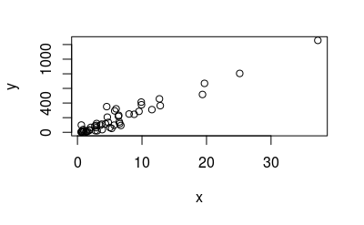

```r
x<- murders$population / 10^6
y<- murders$total
plot(x,y)
```

for a quick plot that avoids accessing variables twice, we can use the *with* function:

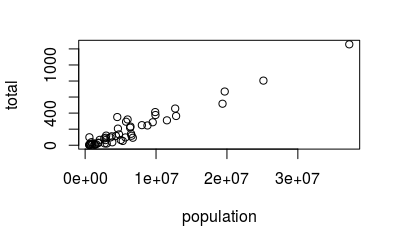

```r
with(murders, plot(population, total))
```

the function *with* lets us use the *murders* column names in the *plot* function. it also works any data frames and any fucntion.

# 2.15.2 hist

we will describe histograms as they relate to distributions in the Data Visualization part of the book. here we will simply note that histograms are a powerful graphical summary of a list of numbers that gives you a general overview of the types of values you have. we can make a histogram of our murder rates by simply typing:

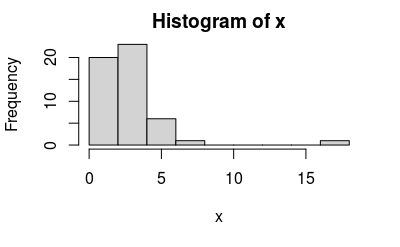

```r
x<- with(murders, total / population * 100000)
hist(x)
```

we can see that there is a wide range of values with most of them between 2 and 3 one very extreme case with a murder rate of more than 15:

```r
murders$state[which.max(x)]
```

```
[1] "District of Columbia"
```

# 2.15.3 boxplot

boxplots will also be described in the Data Visualization part of the book. They provide a more terse summary than histograms, but they are easier to stack with other boxplots. for example, here we can use them to compare the different regions:

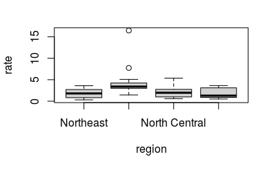

```r
murders$rate<- with(murders, total/population * 100000)
boxplot(rate~region, data=murders)
```

we can see that the South has higher murder rates than the other three regions.

# 2.15.4 image

the image function displays the values in a matirx using color. here is a quick example:

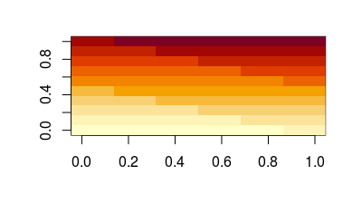

```r
x<- matrix(1:120, 12, 10)
image(x)
```

# 2.16 exercises

1. we made a plot o total murders versus population and noted a strong relationship. not surprisingly, states with larger populations had more murders.

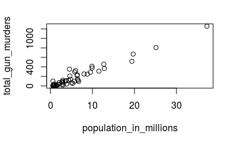

```r
population_in_millions<- murders$population/10^6
total_gun_murders<- murders$total
plot(population_in_millions, total_gun_murders)
```

keep in mind that many states have populations below 5 million and are bunched up. we may gain further insights from making this plot in the log scale. transform the variables using the *log10* transformation and then plot them.

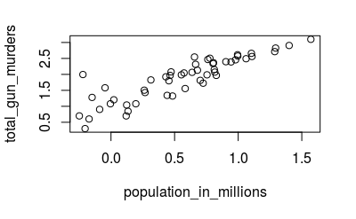

```r
population_in_millions<- log(murders$population/10^6, base=10)
total_gun_murders<- log(murders$total, base=10)
plot(population_in_millions, total_gun_murders)
```

2. create a histogram of the state populations.

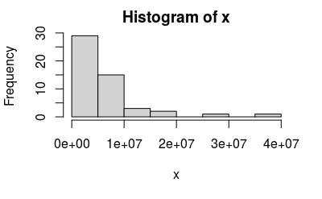

```r
x<- with(murders, population)
hist(x)
```

3. generate boxplots of the state populations by region.

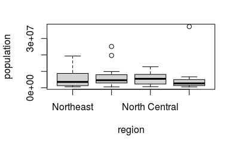

```r
boxplot(population~region, data=murders)
```